# Day 10

# 14.What are the 10 most frequent roles that start with the word"Science"?

```python
science_roles = cast[cast['character'].str.startswith('Science')]
most_frequent_science_roles = science_roles['character'].value_counts().head(10)

print("Top 10 most frequent roles starting with 'Science':")
print(most_frequent_science_roles)
```

```
Top 10 most frequent roles starting with 'Science':
Science Teacher         60
Science Student          9
Science Fair Student     9
Science Fair Judge       6
Science Fair Kid         5
Science Reporter         5
Science Kid              5
Science Club Member      5
Science Promo Cadet      5
Science                  4
Name: character, dtype: int64
```

# 15.Plot the n-values of the roles that Judi Dench has played over her career.

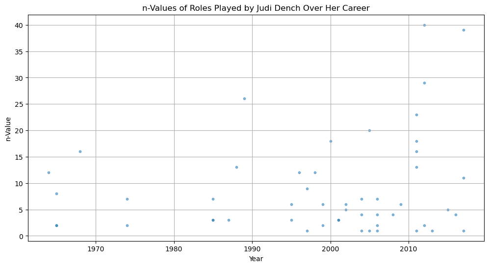

```python
judi_dench_roles = cast[cast['name'] == 'Judi Dench']

judi_dench_roles_with_n = judi_dench_roles.dropna(subset=['n'])

judi_dench_roles_with_n = judi_dench_roles_with_n.sort_values(by='n')

plt.figure(figsize=(12, 6))
plt.scatter(judi_dench_roles_with_n['year'], judi_dench_roles_with_n['n'], s=10, alpha=0.5)
plt.xlabel('Year')
plt.ylabel('n-Value')
plt.title('n-Values of Roles Played by Judi Dench Over Her Career')
plt.grid(True)

plt.show()
```

# 16.Plot the n-values of Cary Grant's roles through his career.

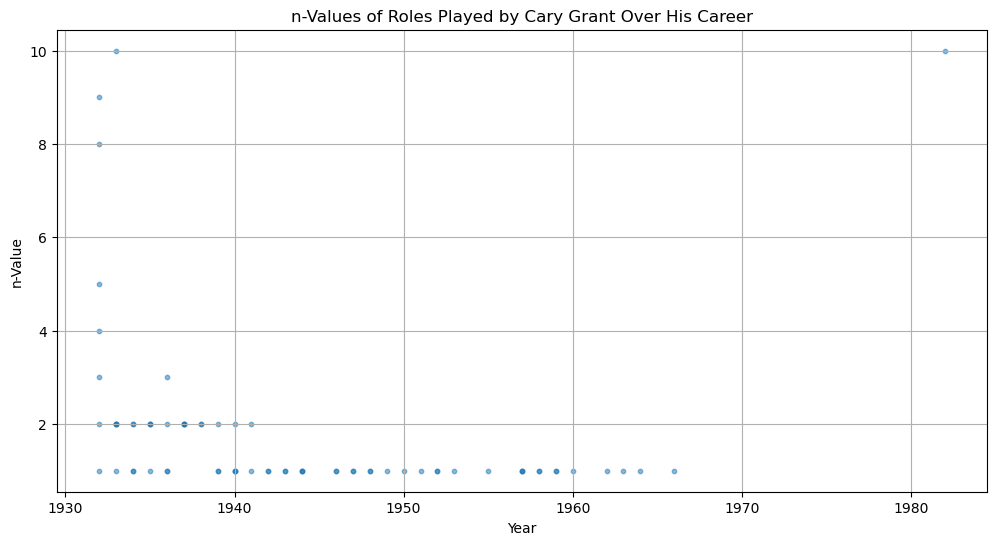

```python
cary_grant_roles = cast[cast['name'] == 'Cary Grant']

cary_grant_roles_with_n = cary_grant_roles.dropna(subset=['n'])

cary_grant_roles_with_n = cary_grant_roles_with_n.sort_values(by='n')

plt.figure(figsize=(12, 6))
plt.scatter(cary_grant_roles_with_n['year'], cary_grant_roles_with_n['n'], s=10, alpha=0.5)
plt.xlabel('Year')
plt.ylabel('n-Value')
plt.title('n-Values of Roles Played by Cary Grant Over His Career')
plt.grid(True)

plt.show()
```

# 17.How many leading (n=1) roles were available to actors, and how many to actresses, in the 1950s?

```python
leading_roles_actors_1950s = cast[(cast['year'] >= 1950) & (cast['year'] <= 1959) & (cast['n'] == 1) & (cast['type'] == 'actor')]

leading_roles_actresses_1950s = cast[(cast['year'] >= 1950) & (cast['year'] <= 1959) & (cast['n'] == 1) & (cast['type'] == 'actress')]

num_leading_roles_actors_1950s = leading_roles_actors_1950s.shape[0]
num_leading_roles_actresses_1950s = leading_roles_actresses_1950s.shape[0]

print("Number of leading roles (n=1) for actors in the 1950s:", num_leading_roles_actors_1950s)
print("Number of leading roles (n=1) for actresses in the 1950s:", num_leading_roles_actresses_1950s)
```

```
Number of leading roles (n=1) for actors in the 1950s: 6692
Number of leading roles (n=1) for actresses in the 1950s: 3040
```

# 18.How many supporting (n=2) roles were available to actors, and how many to actresses, in the 1950s?

```python
supporting_roles_actors_1950s = cast[(cast['year'] >= 1950) & (cast['year'] <= 1959) & (cast['n'] == 2) & (cast['type'] == 'actor')]
supporting_roles_actresses_1950s = cast[(cast['year'] >= 1950) & (cast['year'] <= 1959) & (cast['n'] == 2) & (cast['type'] == 'actress')]

num_supporting_roles_actors_1950s = supporting_roles_actors_1950s.shape[0]
num_supporting_roles_actresses_1950s = supporting_roles_actresses_1950s.shape[0]

print("Number of supporting roles (n=2) for actors in the 1950s:", num_supporting_roles_actors_1950s)
print("Number of supporting roles (n=2) for actresses in the 1950s:", num_supporting_roles_actresses_1950s)
```

```
Number of supporting roles (n=2) for actors in the 1950s: 4640
Number of supporting roles (n=2) for actresses in the 1950s: 4635
```

# Excersies 3

# 1.Using groupby(), plot the number of films that have been released each decade in the history of cinema.

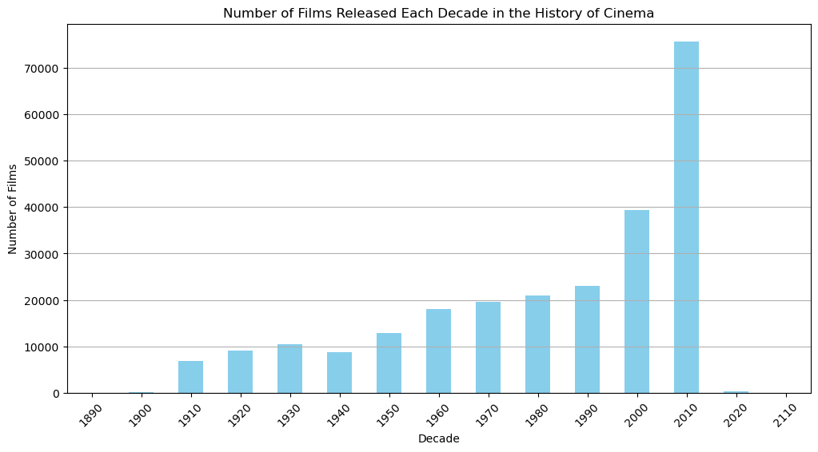

```python
titles['decade'] = (titles['year'] // 10) * 10
films_per_decade = titles.groupby('decade')['title'].count()

plt.figure(figsize=(12, 6))
films_per_decade.plot(kind='bar', color='skyblue')
plt.xlabel('Decade')
plt.ylabel('Number of Films')
plt.title('Number of Films Released Each Decade in the History of Cinema')
plt.xticks(rotation=45)
plt.grid(axis='y')
plt.show()
```

# 2.Use groupby() to plot the number of "Hamlet" films made each decade.

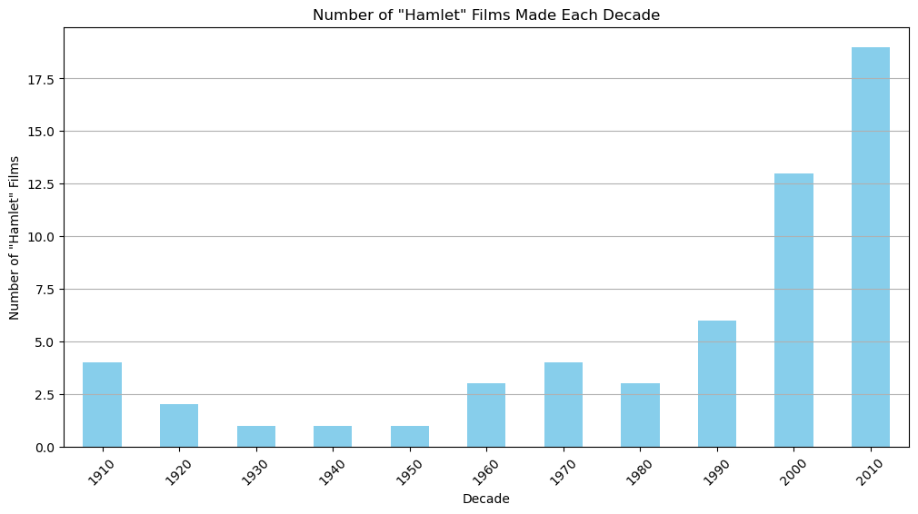

```python
hamlet_films = titles[titles['title'].str.contains('Hamlet', case=False)]

hamlet_films['decade'] = (hamlet_films['year'] // 10) * 10

hamlet_films_per_decade = hamlet_films.groupby('decade')['title'].count()

plt.figure(figsize=(12, 6))
hamlet_films_per_decade.plot(kind='bar', color='skyblue')
plt.xlabel('Decade')
plt.ylabel('Number of "Hamlet" Films')
plt.title('Number of "Hamlet" Films Made Each Decade')
plt.xticks(rotation=45)
plt.grid(axis='y')
plt.show()
```

# 3.How many leading (n=1) roles were available to actors, and how many to actresses, in each year of the 1950s?

```python
leading_roles_by_year = pd.DataFrame(columns=['Year', 'Actors', 'Actresses'])

for year in range(1950, 1960):
    leading_roles_actors = cast[(cast['year'] == year) & (cast['n'] == 1) & (cast['type'] == 'actor')]

    leading_roles_actresses = cast[(cast['year'] == year) & (cast['n'] == 1) & (cast['type'] == 'actress')]

    num_leading_roles_actors = leading_roles_actors.shape[0]
    num_leading_roles_actresses = leading_roles_actresses.shape[0]

    leading_roles_by_year = leading_roles_by_year.append({'Year': year, 'Actors': num_leading_roles_actors, 'Actresses': num_leading_roles_actresses}, ignore_index=True)

print(leading_roles_by_year)
```

```
   Year Actors Actresses
0  1950    625       288
1  1951    651       285
2  1952    613       304
3  1953    664       312
4  1954    636       316
5  1955    648       285
6  1956    668       307
7  1957    739       315
8  1958    715       301
9  1959    733       327
```

# 4.In the 1950s decade taken as a whole, how many total roles were available to actors, and how many to actresses, for each "n" number 1 through 5?

```python
roles_1950s = cast[(cast['year'] >= 1950) & (cast['year'] <= 1959)]

n_values = [1, 2, 3, 4, 5]

roles_by_n = pd.DataFrame(columns=['n', 'Actors', 'Actresses'])

for n in n_values:
    roles_actors = roles_1950s[(roles_1950s['n'] == n) & (roles_1950s['type'] == 'actor')]

    roles_actresses = roles_1950s[(roles_1950s['n'] == n) & (roles_1950s['type'] == 'actress')]

    num_roles_actors = roles_actors.shape[0]
    num_roles_actresses = roles_actresses.shape[0]

    roles_by_n = roles_by_n.append({'n': n, 'Actors': num_roles_actors, 'Actresses': num_roles_actresses}, ignore_index=True)

print(roles_by_n)
```

```
   n Actors Actresses
0  1   6692      3040
1  2   4640      4635
2  3   5654      3201
3  4   5663      2881
4  5   5674      2592
```

# 5.Use groupby() to determine how many roles are listed for each of the Pink Panther movies.

```python
pink_panther_roles = cast[cast['title'].str.contains('Pink Panther', case=False, na=False)]
roles_per_movie = pink_panther_roles.groupby('title')['character'].count().reset_index()

roles_per_movie.columns = ['Movie', 'Number of Roles']

print(roles_per_movie)
```

```
                            Movie  Number of Roles
0       Curse of the Pink Panther               67
1     Revenge of the Pink Panther               68
2         Son of the Pink Panther               46
3                The Pink Panther              111
4              The Pink Panther 2               84
5  The Pink Panther Strikes Again               70
6  The Return of the Pink Panther               30
7       Trail of the Pink Panther               41
```

# 6.List, in order by year, each of the films in which Frank Oz has played more than 1 role.

```python
frank_oz_roles = cast[cast['name'] == 'Frank Oz']
roles_per_movie = frank_oz_roles.groupby(['title', 'year'])['character'].count().reset_index()

multiple_roles_movies = roles_per_movie[roles_per_movie['character'] > 1]

multiple_roles_movies = multiple_roles_movies.sort_values('year')

print(multiple_roles_movies)
```

```
                                   title  year  character
24                      The Muppet Movie  1979          8
0         An American Werewolf in London  1981          2
22                The Great Muppet Caper  1981          6
20                      The Dark Crystal  1982          2
25            The Muppets Take Manhattan  1984          7
2                       Follow That Bird  1985          3
23            The Muppet Christmas Carol  1992          7
7                 Muppet Treasure Island  1996          4
8                     Muppets from Space  1999          4
18  The Adventures of Elmo in Grouchland  1999          3
```

# 7.List each of the characters that Frank Oz has portrayed at least twice.

```python
frank_oz_roles = cast[cast['name'] == 'Frank Oz']

character_counts = frank_oz_roles.groupby('character')['name'].count().reset_index()

characters_portrayed_at_least_twice = character_counts[character_counts['name'] >= 2]

print(characters_portrayed_at_least_twice)
```

```
         character  name
0           Animal     6
2             Bert     3
5   Cookie Monster     5
10     Fozzie Bear     4
15          Grover     2
18      Miss Piggy     6
25   Sam the Eagle     5
34            Yoda     6
```

# Excersise 4

# 1.define a year as a "Superman year" whose films feature more Superman characters tham batman.how many years in filims history have been superman years?

```python
superman_batman_df=cast[(cast['character']=='Superman') | (cast['character']=='Batman')]
character_counts=superman_batman_df.groupby(['year','character']).size().unstack(fill_value=0)
superman_years=(character_counts['Superman']>character_counts['Batman']).sum()
print("no of superman years:",superman_years)
```

```
no of superman years: 11
```

# 2.How many years have been "Batman years",with more Batman characters then Superman characters?

```python
superman_batman_df=cast[(cast['character']=='Superman') | (cast['character']=='Batman')]
character_counts=superman_batman_df.groupby(['year','character']).size().unstack(fill_value=0)
batman_years=(character_counts['Batman']>character_counts['Superman']).sum()
print("no of batman yaers:",batman_years)
```

```
no of batman yaers: 27
```

# 3.plot the number of actor roles each year and the number of actress roles each year over the history of film.

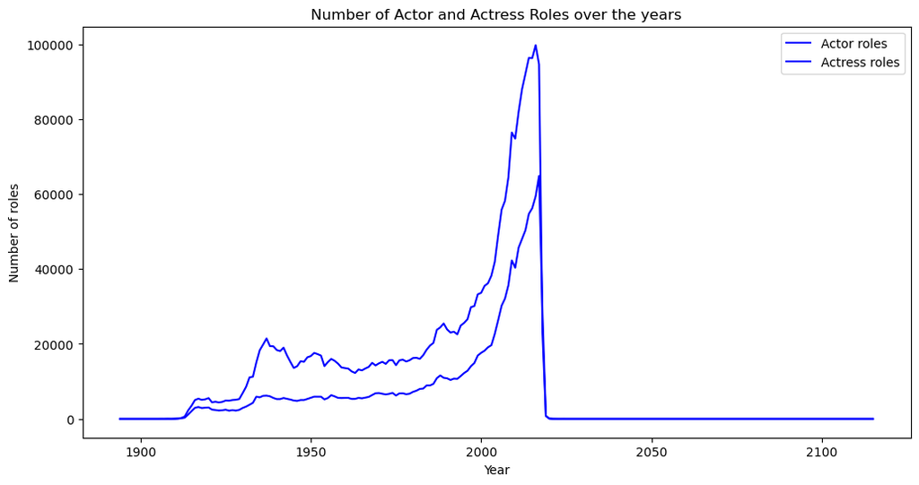

```python
actor_df=cast[cast['type']=='actor']
actress_df=cast[cast['type']=='actress']
actor_counts=actor_df.groupby('year').size()
actress_counts=actress_df.groupby('year').size()
plt.figure(figsize=(12,6))
plt.plot(actor_counts.index,actor_counts.values,label='Actor roles',color='blue')
plt.plot(actress_counts.index,actress_counts.values,label='Actress roles',color='blue')

plt.xlabel('Year')
plt.ylabel('Number of roles')
plt.title('Number of Actor and Actress Roles over the years')
plt.legend()

plt.show()
```

# 4.Plot the number of actor roles each year and the number of actress roles ecach year,but this time as a kind='area plot'.

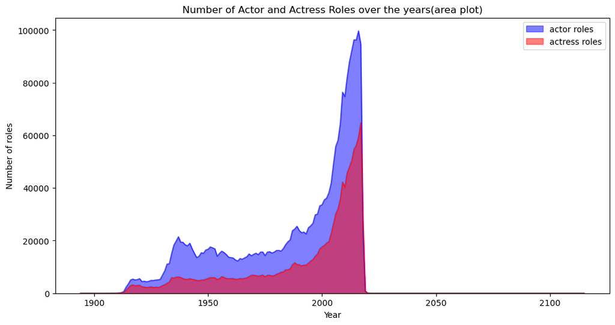

```python
actor_df=cast[cast['type']=='actor']
actress_df=cast[cast['type']=='actress']

actor_counts=actor_df.groupby('year').size()
actress_counts=actress_df.groupby('year').size()

plt.figure(figsize=(12,6))
actor_counts.plot(kind='area',label='actor roles',color='blue',alpha=0.5)
actress_counts.plot(kind='area',label='actress roles',color='red',alpha=0.5)


plt.xlabel('Year')
plt.ylabel('Number of roles')
plt.title('Number of Actor and Actress Roles over the years(area plot)')
plt.legend()

plt.show()
```

# 5.plot the difference between the number of actor roles each year and the number of actress roles each year over the history of film.

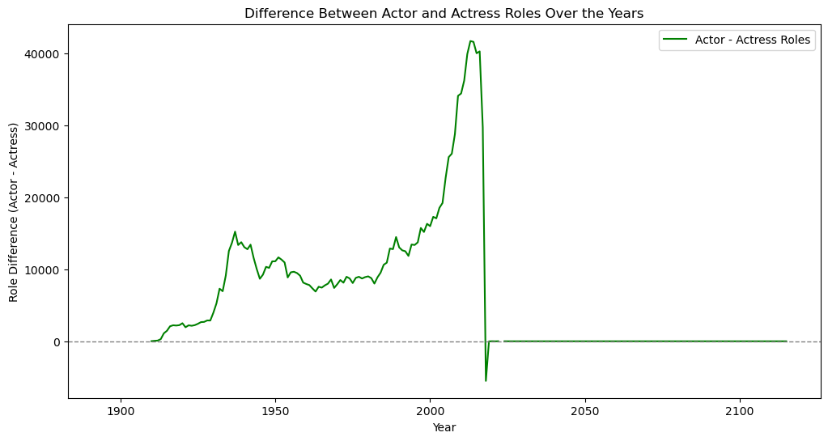

```python
actor_df = cast[cast['type'] == 'actor']
actress_df = cast[cast['type'] == 'actress']

actor_counts = actor_df.groupby('year').size()
actress_counts = actress_df.groupby('year').size()

role_difference = actor_counts - actress_counts

plt.figure(figsize=(12, 6))
plt.plot(role_difference.index, role_difference.values, label='Actor - Actress Roles', color='green')

plt.xlabel('Year')
plt.ylabel('Role Difference (Actor - Actress)')
plt.title('Difference Between Actor and Actress Roles Over the Years')
plt.axhline(y=0, color='gray', linestyle='--', linewidth=1)
plt.legend()

plt.show()
```

# 6.Plot the fraction of roles that have been 'actor' roles each year in the history of film.

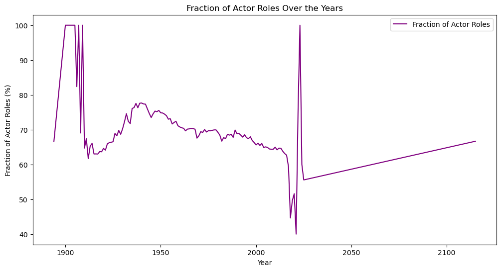

```python
total_roles_by_year = cast.groupby('year').size()

actor_roles_by_year = cast[cast['type'] == 'actor'].groupby('year').size()

fraction_actor_roles = (actor_roles_by_year / total_roles_by_year) * 100

plt.figure(figsize=(12, 6))
plt.plot(fraction_actor_roles.index, fraction_actor_roles.values, label='Fraction of Actor Roles', color='purple')

plt.xlabel('Year')
plt.ylabel('Fraction of Actor Roles (%)')
plt.title('Fraction of Actor Roles Over the Years')
plt.legend()

plt.show()
```

# 7.Plot the fraction of supporting(n=2) roles that have been 'actor' roles each year in the history of film.

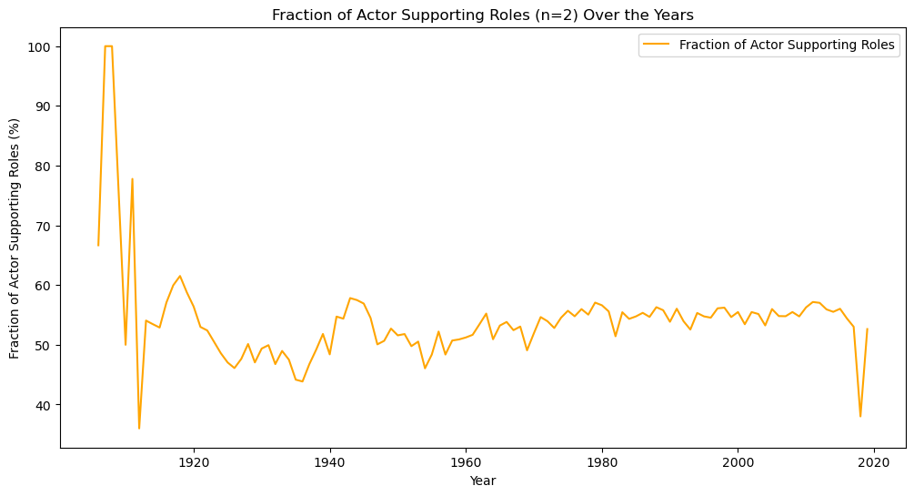

```python
supporting_roles_df = cast[cast['n'] == 2]

total_supporting_roles_by_year = supporting_roles_df.groupby('year').size()

actor_supporting_roles_by_year = supporting_roles_df[supporting_roles_df['type'] == 'actor'].groupby('year').size()

fraction_actor_supporting_roles = (actor_supporting_roles_by_year / total_supporting_roles_by_year) * 100

plt.figure(figsize=(12, 6))
plt.plot(fraction_actor_supporting_roles.index, fraction_actor_supporting_roles.values, label='Fraction of Actor Supporting Roles', color='orange')

plt.xlabel('Year')
plt.ylabel('Fraction of Actor Supporting Roles (%)')
plt.title('Fraction of Actor Supporting Roles (n=2) Over the Years')
plt.legend()

plt.show()
```

# 8.Build a plot with a line for each rank n=1 through n=3,where the line shows what fraction of that rank's roles were 'actor' roles for each year in the history of film.

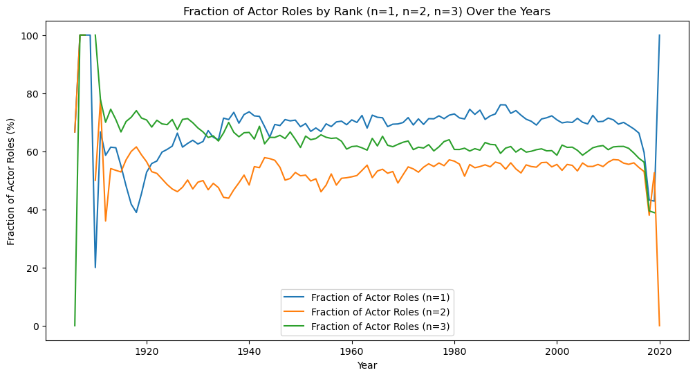

```python
filtered_roles_df = cast[cast['n'].isin([1, 2, 3])]

total_roles_by_year_rank = filtered_roles_df.groupby(['year', 'n']).size().unstack(fill_value=0)

actor_roles_by_year_rank = filtered_roles_df[filtered_roles_df['type'] == 'actor'].groupby(['year', 'n']).size().unstack(fill_value=0)

fraction_actor_roles_by_rank = (actor_roles_by_year_rank / total_roles_by_year_rank) * 100

plt.figure(figsize=(12, 6))
for rank in range(1, 4):
    plt.plot(fraction_actor_roles_by_rank.index, fraction_actor_roles_by_rank[rank], label=f'Fraction of Actor Roles (n={rank})')

plt.xlabel('Year')
plt.ylabel('Fraction of Actor Roles (%)')
plt.title('Fraction of Actor Roles by Rank (n=1, n=2, n=3) Over the Years')
plt.legend()

plt.show()
```

# Exercises 5

# 1.Make a bar plot of the months in which movies with "Christmas" in their title tend to be released in the USA.

[figure not shown]

```python
christmas_movies_df = titles[titles['title'].str.contains("Christmas", case=False, na=False)]

release_dates = pd.to_datetime(christmas_movies_df['year'], format='%Y')

monthly_counts = release_dates.dt.month.value_counts().sort_index()

month_names = ['January', 'February', 'March', 'April', 'May', 'June', 'July', 'August', 'September', 'October', 'November', 'December']

plt.figure(figsize=(10, 6))
plt.bar(month_names, monthly_counts)

plt.xlabel('Month')
plt.ylabel('Number of Christmas Movies Released')
plt.title('Distribution of Christmas Movies Released by Month in the USA')

plt.xticks(rotation=45)
plt.tight_layout()
plt.show()
```

# 2.Make a bar plot of the months in which movies whose titles start with "The Hobbit" are released in the USA.

[figure not shown]

```python
hobbit_movies_df = titles[titles['title'].str.startswith("The Hobbit", na=False)]

release_dates = pd.to_datetime(hobbit_movies_df['year'], format='%Y')

monthly_counts = release_dates.dt.month.value_counts().sort_index()

month_names = ['January', 'February', 'March', 'April', 'May', 'June', 'July', 'August', 'September', 'October', 'November', 'December']

plt.figure(figsize=(10, 6))
plt.bar(month_names, monthly_counts)

plt.xlabel('Month')
plt.ylabel('Number of "The Hobbit" Movies Released')
plt.title('Distribution of "The Hobbit" Movies Released by Month in the USA')

plt.xticks(rotation=45)
plt.tight_layout()
plt.show()
```

# 3.Make a bar plot of the day of the week on which movies with "Romance" in their title tend to be released in the USA.

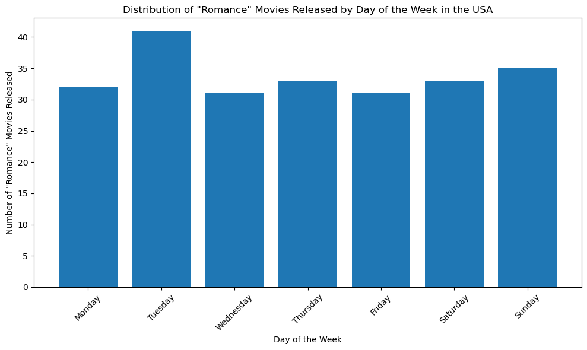

```python
romance_movies_df = titles[titles['title'].str.contains("Romance", case=False, na=False)]

release_dates = pd.to_datetime(romance_movies_df['year'], format='%Y')

weekday_counts = release_dates.dt.dayofweek.value_counts().sort_index()

weekday_names = ['Monday', 'Tuesday', 'Wednesday', 'Thursday', 'Friday', 'Saturday', 'Sunday']

plt.figure(figsize=(10, 6))
plt.bar(weekday_names, weekday_counts)

plt.xlabel('Day of the Week')
plt.ylabel('Number of "Romance" Movies Released')
plt.title('Distribution of "Romance" Movies Released by Day of the Week in the USA')

plt.xticks(rotation=45)
plt.tight_layout()
plt.show()
```

# 4.Make a bar plot of the day of the week on which movies with "Action" in their title tend to be released in the USA.

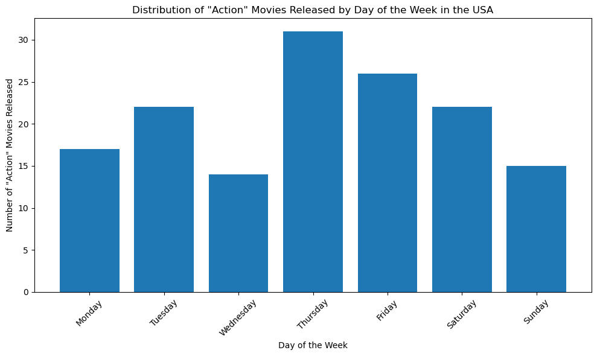

```python
action_movies_df = titles[titles['title'].str.contains("Action", case=False, na=False)]

release_dates = pd.to_datetime(action_movies_df['year'], format='%Y')

weekday_counts = release_dates.dt.dayofweek.value_counts().sort_index()

weekday_names = ['Monday', 'Tuesday', 'Wednesday', 'Thursday', 'Friday', 'Saturday', 'Sunday']

plt.figure(figsize=(10, 6))
plt.bar(weekday_names, weekday_counts)

plt.xlabel('Day of the Week')
plt.ylabel('Number of "Action" Movies Released')
plt.title('Distribution of "Action" Movies Released by Day of the Week in the USA')

plt.xticks(rotation=45)
plt.tight_layout()
plt.show()
```

# 5.On which date was each Judi Dench movie from the 1990s released in the USA?

```python
judi_dench_movies = titles[titles['star'] == 'Judi Dench']

judi_dench_movies_1990s = judi_dench_movies[(judi_dench_movies['year'] >= 1990) & (judi_dench_movies['year'] <= 1999)]

judi_dench_movie_release_dates = pd.merge(judi_dench_movies_1990s, release_dates, on='title', how='inner')
usa_release_dates = judi_dench_movie_release_dates[judi_dench_movie_release_dates['country'] == 'USA'][['title', 'date']]

print(usa_release_dates)
```

[output not shown]

# 6.In which months do films with Tom Cruise tend to be released in the USA?

```python
tom_cruise_movies = titles[titles['star'] == 'Tom Cruise']
tom_cruise_release_dates = pd.merge(tom_cruise_movies, release_dates, on='title', how='inner')

tom_cruise_release_dates['release_month'] = pd.to_datetime(tom_cruise_release_dates['date']).dt.month
release_month_counts = tom_cruise_release_dates['release_month'].value_counts().sort_index()

print(release_month_counts)
```

[output not shown]

# 7.In which months do films with Judi Dench tend to be released in the USA?

```python
judi_dench_movies = titles[titles['title'] == 'Judi Dench']

judi_dench_release_dates = pd.merge(judi_dench_movies, release_dates, on='title', how='inner')

judi_dench_release_dates['release_month'] = pd.to_datetime(judi_dench_release_dates['date']).dt.month

release_month_counts = judi_dench_release_dates['release_month'].value_counts().sort_index()

print(release_month_counts)
```

[output not shown]